# Assignment3

Whytne Stevens

9/19/2020

# Assignment 3

For this assignment, I altered my original data set to make the analysis and this assignment much easier. For more information on this, I created a new markdown file, which can be found here: https://ses-5215-f2020.github.io/whytnestevens-quant/Assignment1and2-VariableChanges

In addition, I also learned another formatting trick from Julia where you can toggle the code on or off. If you want to see all the code, just click on the black ‘Code’ button on the top right of this page and select ‘Show All Code’.

```r
library(ggplot2)
library(tidycensus)
library(ggthemes)
library(tidyverse)
library(wesanderson)
library(viridis)
person_data_new <- read.csv("persondatanew.csv") %>%
  mutate(struct_type = case_when(
    ENG_label=="N/A - \nOnly Speaks English"~"N/A (less than 5 years old/speaks only English)",
    HHL_label=="Asian and Pacific Island languages"~"Asian and \nPacific Island languages",
    HHL_label=="Other Indo-European languages" ~ "Other Indo-\nEuropean languages",
    COW_label=="Employee of a private for-profit company or business, or of an individual, for wages, salary, or commissions" ~ "Employee of a private \nfor-profit company/business",
    COW_label=="Employee of a private not-for-profit, tax-exempt, or charitable organization" ~ "Employee of a private \nnot-for-profit organization",
    COW_label=="Federal government employee" ~ "Federal government \nemployee",
    COW_label=="Local government employee (city, county, etc.)" ~ "Local government \nemployee",
    COW_label=="Self-employed in own incorporated business, professional practice or farm"~"Self-employed in own \nincorporated business",
    COW_label=="Self-employed in own not incorporated business, professional practice, or farm" ~ "Self-employed in own \nnot incorporated business",
    COW_label=="Working without pay in family business or farm" ~ "Working without pay \nin family business or farm"))
```

# Relationships between two continuous variables

Below are the correlation tests and associated scatterplots with my continuous variables:

- Income (PINCP)
- Work hours per week (WKHP)
- Income to Poverty Ratio (POVPIP)

## Correlation between Total person’s income (PINCP) and Hours worked per week (WKHP) with scatterplots

```r
correlation <- cor.test(person_data_new$PINCP, person_data_new$WKHP)

correlation
```

```
##
##  Pearson's product-moment correlation
##
## data:  person_data_new$PINCP and person_data_new$WKHP
## t = 7.9204, df = 555, p-value = 1.3e-14
## alternative hypothesis: true correlation is not equal to 0
## 95 percent confidence interval:
##  0.2420017 0.3913905
## sample estimates:
##       cor
## 0.3186736
```

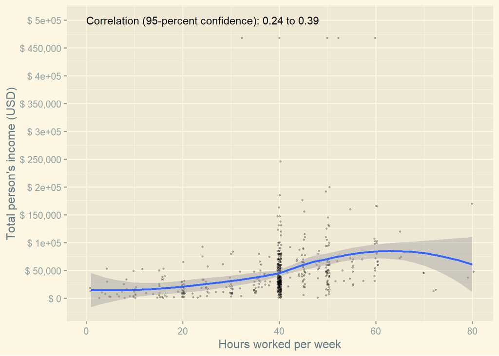

```r
ggplot(person_data_new, aes(x = WKHP, y = PINCP)) +
  geom_point(size = 0.5, alpha = 0.25, position = "jitter") +
  geom_smooth() +
  theme_solarized_2() +
  scale_x_continuous(name = "Hours worked per week") +
  scale_y_continuous(name = "Total person's income (USD)",
                     breaks = seq(0, 500000, by = 50000),
                     labels = paste("$",
                                    prettyNum(seq(0, 500000, by = 50000),
                                              big.mark = ","))) +
  annotate(geom = "text", x = 0, y = 500000,
           label = paste("Correlation (95-percent confidence):",
                         prettyNum(correlation$conf.int[1], digits = 2),
                         "to",
                         prettyNum(correlation$conf.int[2], digits = 2)),
           hjust = 0)
```

## Correlation between Total person’s income (PINCP) and Income to poverty ratio (POVPIP) with scatterplots

```r
correlation2 <- cor.test(person_data_new$PINCP, person_data_new$POVPIP)

correlation2
```

```
##
##  Pearson's product-moment correlation
##
## data:  person_data_new$PINCP and person_data_new$POVPIP
## t = 11.276, df = 555, p-value < 2.2e-16
## alternative hypothesis: true correlation is not equal to 0
## 95 percent confidence interval:
##  0.3616282 0.4969891
## sample estimates:
##       cor
## 0.4317362
```

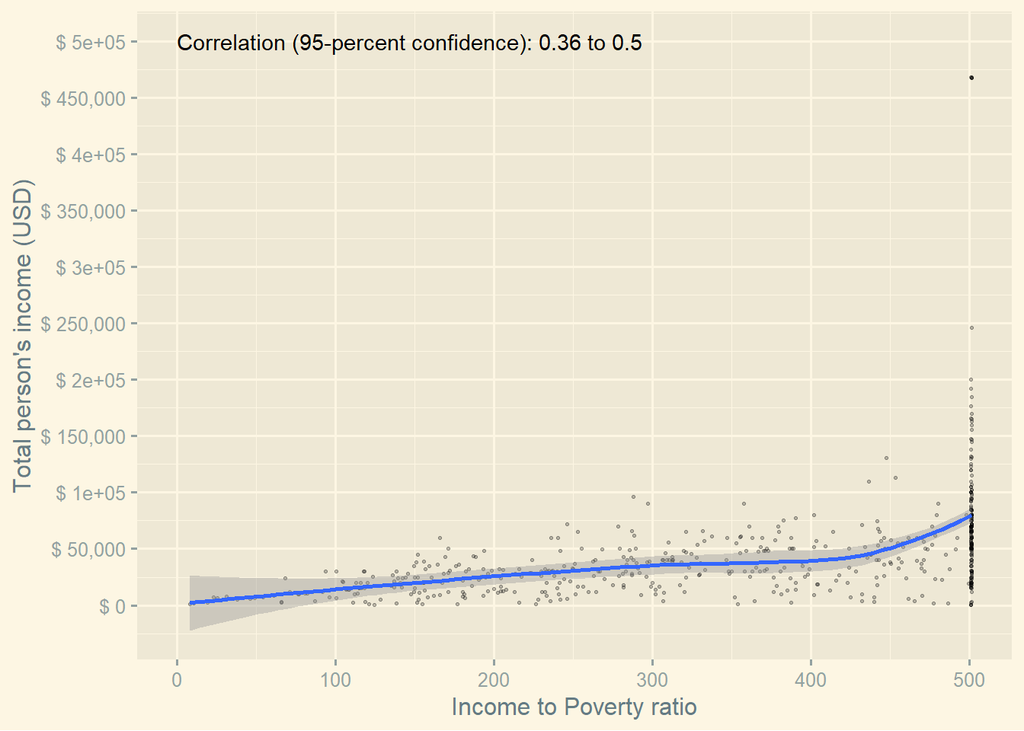

```r
ggplot(person_data_new, aes(x = POVPIP, y = PINCP)) +
  geom_point(size = 0.5, alpha = 0.25, position = "jitter") +
  geom_smooth() +
  theme_solarized_2() +
  scale_x_continuous(name = "Income to Poverty ratio") +
  scale_y_continuous(name = "Total person's income (USD)",
                     breaks = seq(0, 500000, by = 50000),
                     labels = paste("$",
                                    prettyNum(seq(0, 500000, by = 50000),
                                              big.mark = ","))) +
  annotate(geom = "text", x = 0, y = 500000,
           label = paste("Correlation (95-percent confidence):",
                         prettyNum(correlation2$conf.int[1], digits = 2),
                         "to",
                         prettyNum(correlation2$conf.int[2], digits = 2)),
           hjust = 0)
```

## Correlation between Income to poverty ratio (POVPIP) and Hours worked per week (WKHP) with scatterplots

```r
correlation3 <- cor.test(person_data_new$POVPIP, person_data_new$WKHP)

correlation3
```

```
##
##  Pearson's product-moment correlation
##
## data:  person_data_new$POVPIP and person_data_new$WKHP
## t = 3.9394, df = 555, p-value = 9.209e-05
## alternative hypothesis: true correlation is not equal to 0
## 95 percent confidence interval:
##  0.08298738 0.24465588
## sample estimates:
##       cor
## 0.1649292
```

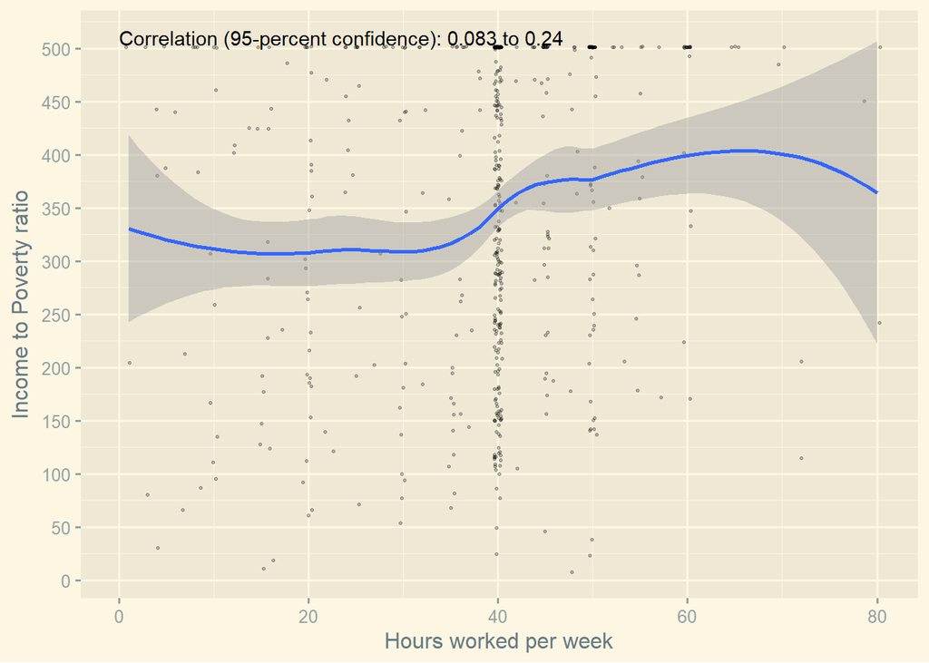

```r
ggplot(person_data_new, aes(x = WKHP, y = POVPIP)) +
  geom_point(size = 0.5, alpha = 0.25, position = "jitter") +
  geom_smooth() +
  theme_solarized_2() +
  scale_x_continuous(name = "Hours worked per week") +
  scale_y_continuous(name = "Income to Poverty ratio",
                     breaks = seq(0, 510, by = 50),
                     labels = paste("",
                                    prettyNum(seq(0, 510, by = 50),
                                              big.mark = ","))) +
  annotate(geom = "text", x = 0, y = 510,
           label = paste("Correlation (95-percent confidence):",
                         prettyNum(correlation3$conf.int[1], digits = 2),
                         "to",
                         prettyNum(correlation3$conf.int[2], digits = 2)),
           hjust = 0)
```

## Results

After doing the correlation tests I discovered the following results:

For all other observations, there was a weak relationship or no relationship at all

# Relationships between a continuous variable and a binary variable

Below are the correlation tests and associated violin plots with my continuous variables and binary categorical variables:

- Income (PINCP) (continuous)
- Work hours per week (WKHP) (continuous)
- Income to Poverty Ratio (POVPIP) (continuous)
- Food Stamps (FS) (Categorical - Binary)

## Total Person’s Income (PINCP) (continuous) and Food Stamps (FS) (Categorical)

```r
difference = t.test(PINCP ~ FS_label == "Yes",
                    data = person_data_new)

difference
```

```
##
##  Welch Two Sample t-test
##
## data:  PINCP by FS_label == "Yes"
## t = 6.6615, df = 192.89, p-value = 2.759e-10
## alternative hypothesis: true difference in means is not equal to 0
## 95 percent confidence interval:
##  16239.48 29900.76
## sample estimates:
## mean in group FALSE  mean in group TRUE
##            49260.68            26190.56
```

```r
difference = t.test(PINCP ~ FS_label == "No",
                    data = person_data_new)

difference
```

```
##
##  Welch Two Sample t-test
##
## data:  PINCP by FS_label == "No"
## t = -6.6615, df = 192.89, p-value = 2.759e-10
## alternative hypothesis: true difference in means is not equal to 0
## 95 percent confidence interval:
##  -29900.76 -16239.48
## sample estimates:
## mean in group FALSE  mean in group TRUE
##            26190.56            49260.68
```

[figure not shown]

```r
ggplot(person_data_new, aes(x = FS_label, y = PINCP)) +
  geom_violin() +
  theme_solarized_2() +
  scale_x_discrete(name = "Does this person take part in the \nSupplemental Nutrition Assistance Program (SNAP)?",
                   labels = c("Yes", "No")) +
 scale_y_continuous(name = "Total person's income (USD)",
                     breaks = seq(0, 500000, by = 50000),
                     labels = paste("$",
                                    prettyNum(seq(0, 500000, by = 50000),
                                              big.mark = ","))) +
  annotate(geom = "text", x = 1.5, y = 400000,  size = 3,
           label = paste("Difference in means\n(95% confidence):\n$",
                         prettyNum(abs(difference$conf.int[2]),
                                   digits = 1), " to $",
                         prettyNum(abs(difference$conf.int[1]),
                                   digits = 1),
                         sep = "")) +
  annotate(geom = "text", x = 1, y = difference$estimate[1], size = 3,
           label = paste("Mean (95% confidence):\n$",
                         prettyNum(difference$estimate[1], digits = 1))) +
  annotate(geom = "text", x = 2, y = difference$estimate[2], size = 3,
           label = paste("Mean (95% confidence):\n$",
                         prettyNum(difference$estimate[2], digits = 1)))
```

## Hours worked per week (WKHP) (continuous) and Food Stamps (FS) (Categorical)

```r
difference2 = t.test(WKHP ~ FS_label == "Yes",
                    data = person_data_new)

difference2
```

```
##
##  Welch Two Sample t-test
##
## data:  WKHP by FS_label == "Yes"
## t = 0.70617, df = 67.097, p-value = 0.4825
## alternative hypothesis: true difference in means is not equal to 0
## 95 percent confidence interval:
##  -2.151429  4.507294
## sample estimates:
## mean in group FALSE  mean in group TRUE
##            38.67793            37.50000
```

```r
difference2 = t.test(WKHP ~ FS_label == "No",
                    data = person_data_new)

difference2
```

```
##
##  Welch Two Sample t-test
##
## data:  WKHP by FS_label == "No"
## t = -0.70617, df = 67.097, p-value = 0.4825
## alternative hypothesis: true difference in means is not equal to 0
## 95 percent confidence interval:
##  -4.507294  2.151429
## sample estimates:
## mean in group FALSE  mean in group TRUE
##            37.50000            38.67793
```

## Income to Poverty Ratio (POVPIP) (continuous) and Food Stamps (FS) (Categorical)

```r
difference3 = t.test(POVPIP ~ FS_label == "Yes",
                    data = person_data_new)

difference3
```

```
##
##  Welch Two Sample t-test
##
## data:  POVPIP by FS_label == "Yes"
## t = 6.4184, df = 65.589, p-value = 1.767e-08
## alternative hypothesis: true difference in means is not equal to 0
## 95 percent confidence interval:
##   86.9830 165.5466
## sample estimates:
## mean in group FALSE  mean in group TRUE
##            360.1352            233.8704
```

```r
difference3 = t.test(POVPIP ~ FS_label == "No",
                    data = person_data_new)

difference3
```

```
##
##  Welch Two Sample t-test
##
## data:  POVPIP by FS_label == "No"
## t = -6.4184, df = 65.589, p-value = 1.767e-08
## alternative hypothesis: true difference in means is not equal to 0
## 95 percent confidence interval:
##  -165.5466  -86.9830
## sample estimates:
## mean in group FALSE  mean in group TRUE
##            233.8704            360.1352
```

[figure not shown]

```r
ggplot(person_data_new, aes(x = FS_label, y = POVPIP)) +
  geom_violin() +
  theme_solarized_2() +
  scale_x_discrete(name = "Does this person take part in the \nSupplemental Nutrition Assistance Program (SNAP)?",
                   labels = c("Yes", "No"))  +
 scale_y_continuous(name = "Income to Poverty Ratio",
                     breaks = seq(0, 510, by = 50),
                     labels = paste("",
                                    prettyNum(seq(0, 510, by = 50),
                                              big.mark = ","))) +
  annotate(geom = "text", x = 1.65, y = 450,  size = 3,
           label = paste("Difference in means\n(95% confidence):\n",
                         prettyNum(abs(difference3$conf.int[2]),
                                   digits = 0), " to ",
                         prettyNum(abs(difference3$conf.int[1]),
                                   digits = 0),
                         sep = "")) +
  annotate(geom = "text", x = 1, y = difference3$estimate[1], size = 3,
           label = paste("Mean (95% confidence):\n",
                         prettyNum(difference3$estimate[1], digits = 0))) +
  annotate(geom = "text", x = 2, y = difference3$estimate[2], size = 3,
           label = paste("Mean (95% confidence):\n",
                         prettyNum(difference3$estimate[2], digits = 0)))
```

## Results

After doing the difference tests I discovered the following results:

- A strong significant relationship between Total Person’s Income and Food Stamps
- A strong significant relationship between Income to Poverty Ratio and Food Stamps

For all other observations, there was a weak relationship or no relationship at all

# Relationships between a continuous variable and a categorical variable (three or more levels)

- Income (PINCP) (continuous)
- Work hours per week (WKHP) (continuous)
- Income to Poverty Ratio (POVPIP) (continuous)
- Class of Worker (COW) (categorical)
- English ability (ENG) (categorical)
- Household Language (HHL) (categorical)

## Total Person’s Income (PINCP) (continuous) and Class of Worker (COW) (categorical)

```r
anova_pincp_cow <- aov(PINCP ~ COW_label, data = person_data_new)

summary(anova_pincp_cow)
```

```
##              Df    Sum Sq   Mean Sq F value   Pr(>F)
## COW_label     7 1.221e+11 1.744e+10   6.645 1.46e-07 ***
## Residuals   549 1.441e+12 2.624e+09
## ---
## Signif. codes:  0 '***' 0.001 '**' 0.01 '*' 0.05 '.' 0.1 ' ' 1
```

```r
differences <- TukeyHSD(anova_pincp_cow)

as_tibble(cbind(pair = row.names(differences$COW_label),
                differences$RAC1P_label))
```

```
## # A tibble: 28 x 1
##    pair
##    <chr>
##  1 Employee of a private not-for-profit, tax-exempt, or charitable organization~
##  2 Federal government employee-Employee of a private for-profit company or busi~
##  3 Local government employee (city, county, etc.)-Employee of a private for-pro~
##  4 Self-employed in own incorporated business, professional practice or farm-Em~
##  5 Self-employed in own not incorporated business, professional practice, or fa~
##  6 State government employee-Employee of a private for-profit company or busine~
##  7 Working without pay in family business or farm-Employee of a private for-pro~
##  8 Federal government employee-Employee of a private not-for-profit, tax-exempt~
##  9 Local government employee (city, county, etc.)-Employee of a private not-for~
## 10 Self-employed in own incorporated business, professional practice or farm-Em~
## # ... with 18 more rows
```

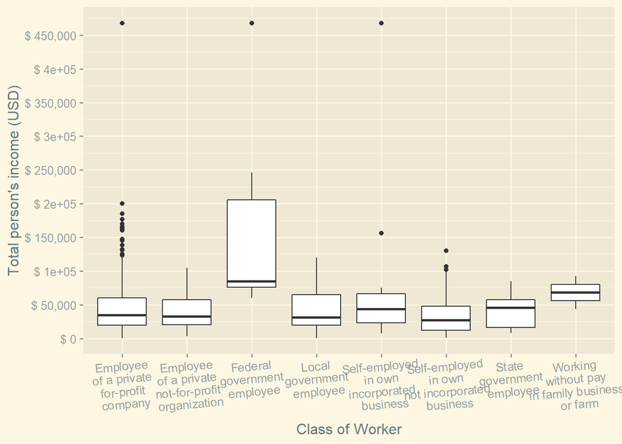

```r
ggplot(person_data_new, aes(x = COW_label, y = PINCP)) +
  geom_boxplot() +
  theme_solarized_2() +
  theme(axis.text.x = element_text(angle = 5)) +
  scale_x_discrete(name = "Class of Worker",
                   labels = c("Employee \nof a private \nfor-profit \ncompany",
                  "Employee \nof a private \nnot-for-profit \norganization",
                   "Federal \ngovernment \nemployee",
                   "Local \ngovernment \nemployee",
                   "Self-employed \nin own \nincorporated \nbusiness",
                   "Self-employed \nin own \nnot incorporated \nbusiness",
                   "State \ngovernment \nemployee",
                  "Working \nwithout pay \nin family business \nor farm")) +
  scale_y_continuous(name = "Total person's income (USD)",
                     breaks = seq(0, 500000, by = 50000),
                     labels = paste("$",
                                    prettyNum(seq(0, 500000, by = 50000),
                                              big.mark = ",")))
```

## Total Person’s Income (PINCP) (continuous) and Household Language (HHL) (categorical)

```r
anova_pincp_hhl <- aov(PINCP ~ HHL_label, data = person_data_new)

summary(anova_pincp_hhl)
```

```
##              Df    Sum Sq   Mean Sq F value   Pr(>F)
## HHL_label     5 5.859e+10 1.172e+10   4.292 0.000772 ***
## Residuals   551 1.504e+12 2.730e+09
## ---
## Signif. codes:  0 '***' 0.001 '**' 0.01 '*' 0.05 '.' 0.1 ' ' 1
```

```r
differences2 <- TukeyHSD(anova_pincp_hhl)

as_tibble(cbind(pair = row.names(differences$HHL_label),
                differences$HHL_label))
```

```
## # A tibble: 0 x 0
```

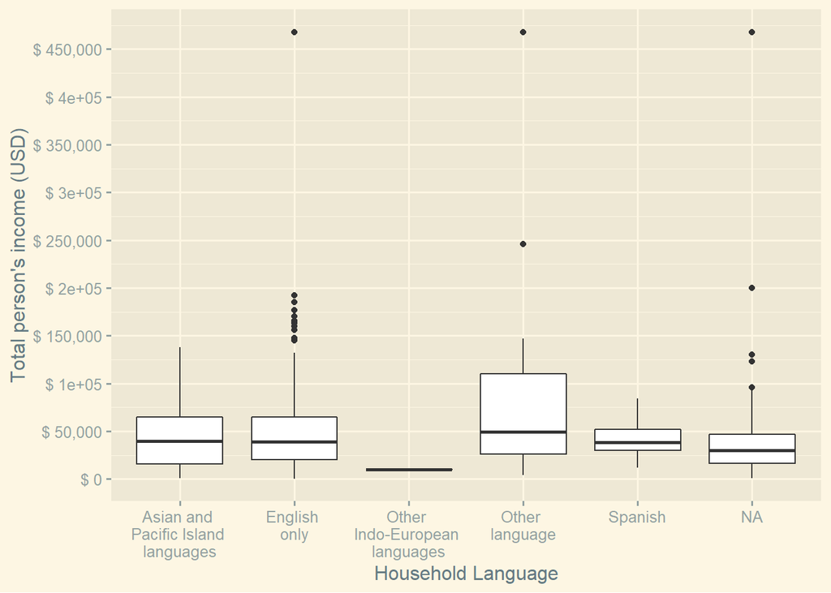

```r
ggplot(person_data_new, aes(x = HHL_label, y = PINCP)) +
  geom_boxplot() +
  theme_solarized_2() +
  theme(axis.text.x = element_text(angle = 0)) +
  scale_x_discrete(name = "Household Language",
                   labels = c("Asian and \nPacific Island \nlanguages",
                  "English \nonly",
                   "Other \nIndo-European \nlanguages",
                   "Other \nlanguage",
                   "Spanish")) +
  scale_y_continuous(name = "Total person's income (USD)",
                     breaks = seq(0, 500000, by = 50000),
                     labels = paste("$",
                                    prettyNum(seq(0, 500000, by = 50000),
                                              big.mark = ",")))
```

## Total Person’s Income (PINCP) (continuous) and English ability (ENG) (categorical)

```r
anova_pincp_eng<- aov(PINCP ~ ENG_label, data = person_data_new)

summary(anova_pincp_eng)
```

```
##              Df    Sum Sq   Mean Sq F value  Pr(>F)
## ENG_label     4 4.591e+10 1.148e+10   4.176 0.00243 **
## Residuals   552 1.517e+12 2.748e+09
## ---
## Signif. codes:  0 '***' 0.001 '**' 0.01 '*' 0.05 '.' 0.1 ' ' 1
```

```r
differences3 <- TukeyHSD(anova_pincp_eng)

as_tibble(cbind(pair = row.names(differences$ENG_label),
                differences$ENG_label))
```

```
## # A tibble: 0 x 0
```

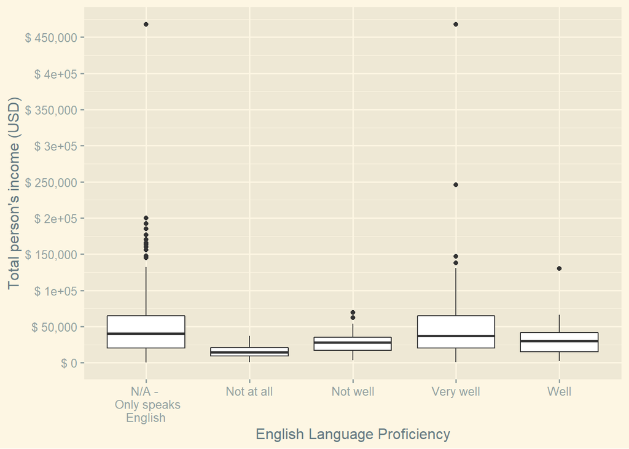

```r
ggplot(person_data_new, aes(x = ENG_label, y = PINCP)) +
  geom_boxplot() +
  theme_solarized_2() +
  theme(axis.text.x = element_text(angle = 0)) +
  scale_x_discrete(name = "English Language Proficiency",
                   labels = c("N/A - \n Only speaks\nEnglish",
                  "Not at all",
                   "Not well",
                   "Very well",
                   "Well")) +
  scale_y_continuous(name = "Total person's income (USD)",
                     breaks = seq(0, 500000, by = 50000),
                     labels = paste("$",
                                    prettyNum(seq(0, 500000, by = 50000),
                                              big.mark = ",")))
```

## Income to Poverty Ratio (POVPIP) (continuous) and Class of Worker (COW) (categorical)

```r
anova_povpip_cow <- aov(POVPIP ~ COW_label, data = person_data_new)

summary(anova_povpip_cow)
```

```
##              Df   Sum Sq Mean Sq F value   Pr(>F)
## COW_label     7   731109  104444   5.223 8.79e-06 ***
## Residuals   549 10978180   19997
## ---
## Signif. codes:  0 '***' 0.001 '**' 0.01 '*' 0.05 '.' 0.1 ' ' 1
```

```r
differences4 <- TukeyHSD(anova_povpip_cow)

as_tibble(cbind(pair = row.names(differences$COW_label),
                differences$COW_label))
```

```
## # A tibble: 28 x 5
##    pair                              diff       lwr        upr       `p adj`
##    <chr>                             <chr>      <chr>      <chr>     <chr>
##  1 Employee of a private not-for-pr~ -6587.128~ -35194.14~ 22019.88~ 0.99696609~
##  2 Federal government employee-Empl~ 113550.37~ 57907.740~ 169193.0~ 2.97850806~
##  3 Local government employee (city,~ -4986.153~ -30514.51~ 20542.20~ 0.99894195~
##  4 Self-employed in own incorporate~ 27837.871~ -11881.24~ 67556.98~ 0.39524935~
##  5 Self-employed in own not incorpo~ -10065.91~ -38267.93~ 18136.09~ 0.95960847~
##  6 State government employee-Employ~ -5232.843~ -47594.80~ 37129.12~ 0.99995006~
##  7 Working without pay in family bu~ 22212.871~ -88272.72~ 132698.4~ 0.99872408~
##  8 Federal government employee-Empl~ 120137.49~ 58523.903~ 181751.0~ 1.47577942~
##  9 Local government employee (city,~ 1600.9756~ -35166.26~ 38368.21~ 0.99999996~
## 10 Self-employed in own incorporate~ 34425      -13300.68~ 82150.68~ 0.35650649~
## # ... with 18 more rows
```

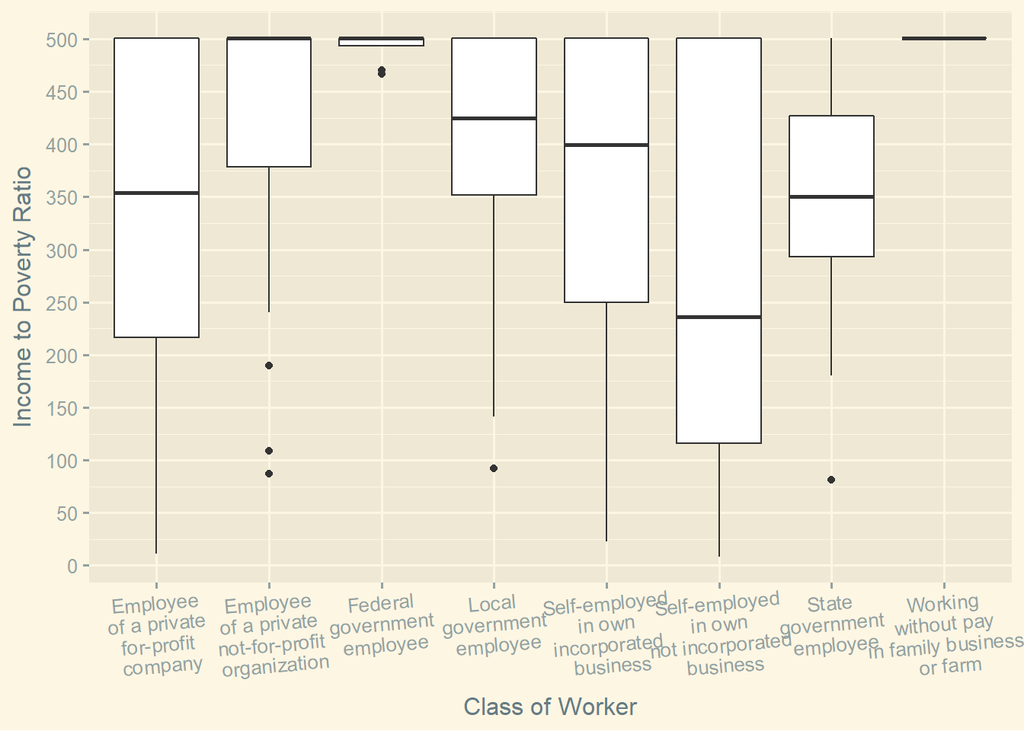

```r
ggplot(person_data_new, aes(x = COW_label, y = POVPIP)) +
  geom_boxplot() +
  theme_solarized_2() +
 theme(axis.text.x = element_text(angle = 5)) +
  scale_x_discrete(name = "Class of Worker",
                   labels = c("Employee \nof a private \nfor-profit \ncompany",
                  "Employee \nof a private \nnot-for-profit \norganization",
                   "Federal \ngovernment \nemployee",
                   "Local \ngovernment \nemployee",
                   "Self-employed \nin own \nincorporated \nbusiness",
                   "Self-employed \nin own \nnot incorporated \nbusiness",
                   "State \ngovernment \nemployee",
                  "Working \nwithout pay \nin family business \nor farm")) +
  scale_y_continuous(name = "Income to Poverty Ratio",
                     breaks = seq(0, 600, by = 50),
                     labels = paste("",
                                    prettyNum(seq(0, 600, by = 50),
                                              big.mark = ",")))
```

## Income to Poverty Ratio (POVPIP) (continuous) and Household Language (HHL) (categorical)

```r
anova_povpip_hhl<- aov(POVPIP ~ HHL_label, data = person_data_new)

summary(anova_povpip_hhl)
```

```
##              Df   Sum Sq Mean Sq F value   Pr(>F)
## HHL_label     5  1287894  257579   13.62 1.51e-12 ***
## Residuals   551 10421395   18914
## ---
## Signif. codes:  0 '***' 0.001 '**' 0.01 '*' 0.05 '.' 0.1 ' ' 1
```

```r
differences5 <- TukeyHSD(anova_povpip_hhl)

as_tibble(cbind(pair = row.names(differences$HHL_label),
                differences$HHL_label))
```

```
## # A tibble: 0 x 0
```

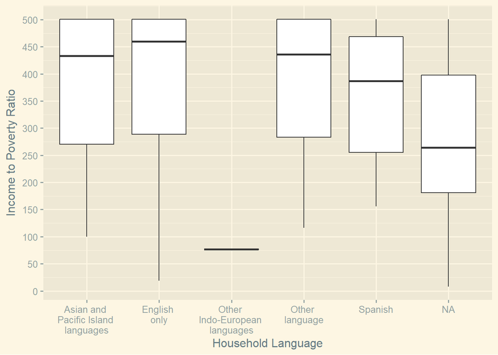

```r
ggplot(person_data_new, aes(x = HHL_label, y = POVPIP)) +
  geom_boxplot() +
  theme_solarized_2() +
   theme(axis.text.x = element_text(angle = 0)) +
  scale_x_discrete(name = "Household Language",
                   labels = c("Asian and \nPacific Island \nlanguages",
                  "English \nonly",
                   "Other \nIndo-European \nlanguages",
                   "Other \nlanguage",
                   "Spanish")) +
  scale_y_continuous(name = "Income to Poverty Ratio",
                     breaks = seq(0, 600, by = 50),
                     labels = paste("",
                                    prettyNum(seq(0, 600, by = 50),
                                              big.mark = ",")))
```

## Income to Poverty Ratio (POVPIP) (continuous) and English ability (ENG) (categorical)

```r
anova_povpip_eng <- aov(POVPIP ~ ENG_label, data = person_data_new)

summary(anova_povpip_eng)
```

```
##              Df   Sum Sq Mean Sq F value   Pr(>F)
## ENG_label     4  1423358  355839    19.1 1.01e-14 ***
## Residuals   552 10285931   18634
## ---
## Signif. codes:  0 '***' 0.001 '**' 0.01 '*' 0.05 '.' 0.1 ' ' 1
```

```r
differences6 <- TukeyHSD(anova_povpip_eng)

as_tibble(cbind(pair = row.names(differences$ENG_label),
                differences$ENG_label))
```

```
## # A tibble: 0 x 0
```

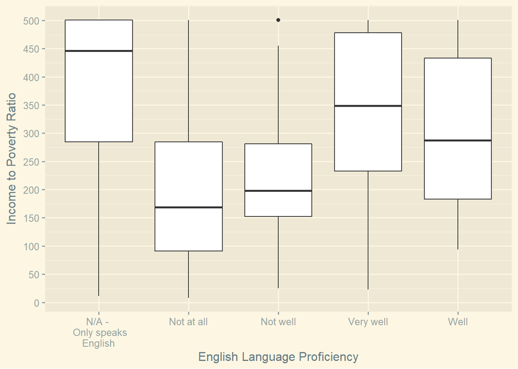

```r
ggplot(person_data_new, aes(x = ENG_label, y = POVPIP)) +
  geom_boxplot() +
  theme_solarized_2() +
  theme(axis.text.x = element_text(angle = 0)) +
  scale_x_discrete(name = "English Language Proficiency",
                   labels = c("N/A - \n Only speaks\nEnglish",
                  "Not at all",
                   "Not well",
                   "Very well",
                   "Well")) +
  scale_y_continuous(name = "Income to Poverty Ratio",
                     breaks = seq(0, 600, by = 50),
                     labels = paste("",
                                    prettyNum(seq(0, 600, by = 50),
                                              big.mark = ",")))
```

## Work hours per week (WKHP) (continuous) and Class of Worker (COW) (categorical)

```r
anova_wkhp_cow<- aov(WKHP ~ COW_label, data = person_data_new)

summary(anova_wkhp_cow)
```

```
##              Df Sum Sq Mean Sq F value Pr(>F)
## COW_label     7    781   111.6   0.721  0.655
## Residuals   549  85034   154.9
```

```r
differences7 <- TukeyHSD(anova_wkhp_cow)

as_tibble(cbind(pair = row.names(differences$COW_label),
                differences$COW_label))
```

```
## # A tibble: 28 x 5
##    pair                              diff       lwr        upr       `p adj`
##    <chr>                             <chr>      <chr>      <chr>     <chr>
##  1 Employee of a private not-for-pr~ -6587.128~ -35194.14~ 22019.88~ 0.99696609~
##  2 Federal government employee-Empl~ 113550.37~ 57907.740~ 169193.0~ 2.97850806~
##  3 Local government employee (city,~ -4986.153~ -30514.51~ 20542.20~ 0.99894195~
##  4 Self-employed in own incorporate~ 27837.871~ -11881.24~ 67556.98~ 0.39524935~
##  5 Self-employed in own not incorpo~ -10065.91~ -38267.93~ 18136.09~ 0.95960847~
##  6 State government employee-Employ~ -5232.843~ -47594.80~ 37129.12~ 0.99995006~
##  7 Working without pay in family bu~ 22212.871~ -88272.72~ 132698.4~ 0.99872408~
##  8 Federal government employee-Empl~ 120137.49~ 58523.903~ 181751.0~ 1.47577942~
##  9 Local government employee (city,~ 1600.9756~ -35166.26~ 38368.21~ 0.99999996~
## 10 Self-employed in own incorporate~ 34425      -13300.68~ 82150.68~ 0.35650649~
## # ... with 18 more rows
```

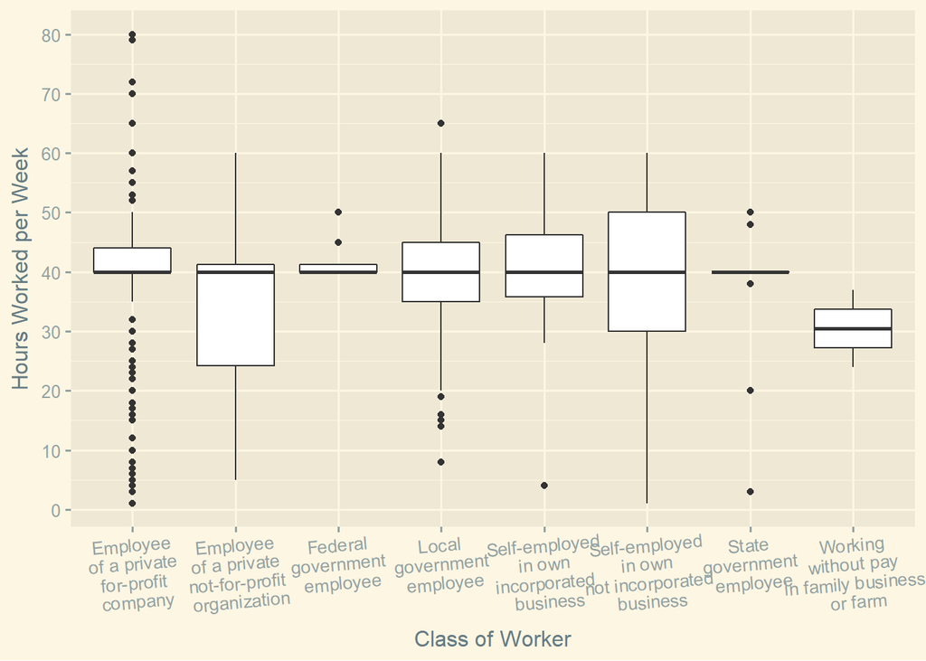

```r
ggplot(person_data_new, aes(x = COW_label, y = WKHP)) +
  geom_boxplot() +
  theme_solarized_2() +
theme(axis.text.x = element_text(angle = 5)) +
  scale_x_discrete(name = "Class of Worker",
                   labels = c("Employee \nof a private \nfor-profit \ncompany",
                  "Employee \nof a private \nnot-for-profit \norganization",
                   "Federal \ngovernment \nemployee",
                   "Local \ngovernment \nemployee",
                   "Self-employed \nin own \nincorporated \nbusiness",
                   "Self-employed \nin own \nnot incorporated \nbusiness",
                   "State \ngovernment \nemployee",
                  "Working \nwithout pay \nin family business \nor farm")) +
  scale_y_continuous(name = "Hours Worked per Week",
                     breaks = seq(0, 100, by = 10),
                     labels = paste("",
                                    prettyNum(seq(0, 100, by = 10),
                                              big.mark = ",")))
```

## Work hours per week (WKHP) (continuous) and Household Language (HHL) (categorical)

```r
anova_wkhp_hhl <- aov(WKHP ~ HHL_label, data = person_data_new)

summary(anova_wkhp_hhl)
```

```
##              Df Sum Sq Mean Sq F value Pr(>F)
## HHL_label     5    345   69.05   0.445  0.817
## Residuals   551  85470  155.12
```

## Work hours per week (WKHP) (continuous) and English ability (ENG) (categorical)

```r
anova_wkhp_eng <- aov(WKHP ~ ENG_label, data = person_data_new)

summary(anova_wkhp_eng)
```

```
##              Df Sum Sq Mean Sq F value Pr(>F)
## ENG_label     4    187   46.73   0.301  0.877
## Residuals   552  85628  155.12
```

## Results

For all other observations, there was a weak relationship or no relationship at all

# Relationships between two categorical variables

Below are the Chi-Square tests for my categorical variables:

- Class of Worker (COW) (categorical)
- English ability (ENG) (categorical)
- Household Language (HHL) (categorical)
- Food Stamps (FS)(Categorical)

## Class of Worker (COW) (categorical) and English ability (ENG) (categorical)

```r
chi_sq_cow_eng <- chisq.test(person_data_new$COW_label, person_data_new$ENG_label ==
                       "N/A (less than 5 years old/speaks only English)")
chi_sq_cow_eng
```

```
##
##  Pearson's Chi-squared test
##
## data:  person_data_new$COW_label and person_data_new$ENG_label == "N/A (less than 5 years old/speaks only English)"
## X-squared = 15.994, df = 7, p-value = 0.02517
```

```r
chi_sq_cow_eng$observed
```

```
##
## person_data_new$COW_label                                                                                      FALSE
##   Employee of a private for-profit company or business, or of an individual, for wages, salary, or commissions   183
##   Employee of a private not-for-profit, tax-exempt, or charitable organization                                     7
##   Federal government employee                                                                                      2
##   Local government employee (city, county, etc.)                                                                  11
##   Self-employed in own incorporated business, professional practice or farm                                        9
##   Self-employed in own not incorporated business, professional practice, or farm                                  19
##   State government employee                                                                                        5
##   Working without pay in family business or farm                                                                   1
##
## person_data_new$COW_label                                                                                      TRUE
##   Employee of a private for-profit company or business, or of an individual, for wages, salary, or commissions  228
##   Employee of a private not-for-profit, tax-exempt, or charitable organization                                   25
##   Federal government employee                                                                                     6
##   Local government employee (city, county, etc.)                                                                 30
##   Self-employed in own incorporated business, professional practice or farm                                       7
##   Self-employed in own not incorporated business, professional practice, or farm                                 14
##   State government employee                                                                                       9
##   Working without pay in family business or farm                                                                  1
```

```r
chi_sq_cow_eng$expected
```

```
##
## person_data_new$COW_label                                                                                            FALSE
##   Employee of a private for-profit company or business, or of an individual, for wages, salary, or commissions 174.8779174
##   Employee of a private not-for-profit, tax-exempt, or charitable organization                                  13.6157989
##   Federal government employee                                                                                    3.4039497
##   Local government employee (city, county, etc.)                                                                17.4452424
##   Self-employed in own incorporated business, professional practice or farm                                      6.8078995
##   Self-employed in own not incorporated business, professional practice, or farm                                14.0412926
##   State government employee                                                                                      5.9569120
##   Working without pay in family business or farm                                                                 0.8509874
##
## person_data_new$COW_label                                                                                            TRUE
##   Employee of a private for-profit company or business, or of an individual, for wages, salary, or commissions 236.122083
##   Employee of a private not-for-profit, tax-exempt, or charitable organization                                  18.384201
##   Federal government employee                                                                                    4.596050
##   Local government employee (city, county, etc.)                                                                23.554758
##   Self-employed in own incorporated business, professional practice or farm                                      9.192101
##   Self-employed in own not incorporated business, professional practice, or farm                                18.958707
##   State government employee                                                                                      8.043088
##   Working without pay in family business or farm                                                                 1.149013
```

```r
chi_sq_cow_eng2 <- chisq.test(person_data_new$COW_label, person_data_new$ENG_label ==
                       "Very well")
chi_sq_cow_eng2
```

```
##
##  Pearson's Chi-squared test
##
## data:  person_data_new$COW_label and person_data_new$ENG_label == "Very well"
## X-squared = 7.6654, df = 7, p-value = 0.363
```

```r
chi_sq_cow_eng3 <- chisq.test(person_data_new$COW_label, person_data_new$ENG_label ==
                       "Well")
chi_sq_cow_eng3
```

```
##
##  Pearson's Chi-squared test
##
## data:  person_data_new$COW_label and person_data_new$ENG_label == "Well"
## X-squared = 5.997, df = 7, p-value = 0.5401
```

```r
chi_sq_cow_eng4 <- chisq.test(person_data_new$COW_label, person_data_new$ENG_label ==
                       "Not well")
chi_sq_cow_eng4
```

```
##
##  Pearson's Chi-squared test
##
## data:  person_data_new$COW_label and person_data_new$ENG_label == "Not well"
## X-squared = 5.3197, df = 7, p-value = 0.621
```

```r
chi_sq_cow_eng5 <- chisq.test(person_data_new$COW_label, person_data_new$ENG_label ==
                       "Not at all")
chi_sq_cow_eng5
```

```
##
##  Pearson's Chi-squared test
##
## data:  person_data_new$COW_label and person_data_new$ENG_label == "Not at all"
## X-squared = 5.8001, df = 7, p-value = 0.5633
```

## Class of Worker (COW) (categorical) and Household Language (HHL) (categorical)

```r
chi_sq_cow_hhl <- chisq.test(person_data_new$COW_label, person_data_new$HHL_label ==
                       "Asian and Pacific Island languages")
chi_sq_cow_hhl
```

```
##
##  Pearson's Chi-squared test
##
## data:  person_data_new$COW_label and person_data_new$HHL_label == "Asian and Pacific Island languages"
## X-squared = 4.0433, df = 7, p-value = 0.7748
```

```r
chi_sq_cow_hhl2 <- chisq.test(person_data_new$COW_label, person_data_new$HHL_label ==
                       "English only")
chi_sq_cow_hhl2
```

```
##
##  Pearson's Chi-squared test
##
## data:  person_data_new$COW_label and person_data_new$HHL_label == "English only"
## X-squared = 17.471, df = 7, p-value = 0.0146
```

```r
chi_sq_cow_hhl2$observed
```

```
##
## person_data_new$COW_label                                                                                      FALSE
##   Employee of a private for-profit company or business, or of an individual, for wages, salary, or commissions   214
##   Employee of a private not-for-profit, tax-exempt, or charitable organization                                     9
##   Federal government employee                                                                                      2
##   Local government employee (city, county, etc.)                                                                  12
##   Self-employed in own incorporated business, professional practice or farm                                        9
##   Self-employed in own not incorporated business, professional practice, or farm                                  20
##   State government employee                                                                                        7
##   Working without pay in family business or farm                                                                   1
##
## person_data_new$COW_label                                                                                      TRUE
##   Employee of a private for-profit company or business, or of an individual, for wages, salary, or commissions  197
##   Employee of a private not-for-profit, tax-exempt, or charitable organization                                   23
##   Federal government employee                                                                                     6
##   Local government employee (city, county, etc.)                                                                 29
##   Self-employed in own incorporated business, professional practice or farm                                       7
##   Self-employed in own not incorporated business, professional practice, or farm                                 13
##   State government employee                                                                                       7
##   Working without pay in family business or farm                                                                  1
```

```r
chi_sq_cow_hhl2$expected
```

```
##
## person_data_new$COW_label                                                                                           FALSE
##   Employee of a private for-profit company or business, or of an individual, for wages, salary, or commissions 202.179533
##   Employee of a private not-for-profit, tax-exempt, or charitable organization                                  15.741472
##   Federal government employee                                                                                    3.935368
##   Local government employee (city, county, etc.)                                                                20.168761
##   Self-employed in own incorporated business, professional practice or farm                                      7.870736
##   Self-employed in own not incorporated business, professional practice, or farm                                16.233393
##   State government employee                                                                                      6.886894
##   Working without pay in family business or farm                                                                 0.983842
##
## person_data_new$COW_label                                                                                            TRUE
##   Employee of a private for-profit company or business, or of an individual, for wages, salary, or commissions 208.820467
##   Employee of a private not-for-profit, tax-exempt, or charitable organization                                  16.258528
##   Federal government employee                                                                                    4.064632
##   Local government employee (city, county, etc.)                                                                20.831239
##   Self-employed in own incorporated business, professional practice or farm                                      8.129264
##   Self-employed in own not incorporated business, professional practice, or farm                                16.766607
##   State government employee                                                                                      7.113106
##   Working without pay in family business or farm                                                                 1.016158
```

```r
chi_sq_cow_hhl3 <- chisq.test(person_data_new$COW_label, person_data_new$HHL_label ==
                       "Other Indo-European languages")
chi_sq_cow_hhl3
```

```
##
##  Pearson's Chi-squared test
##
## data:  person_data_new$COW_label and person_data_new$HHL_label == "Other Indo-European languages"
## X-squared = 14.73, df = 7, p-value = 0.03962
```

```r
chi_sq_cow_hhl4 <- chisq.test(person_data_new$COW_label, person_data_new$HHL_label ==
                       "Other language")
chi_sq_cow_hhl4
```

```
##
##  Pearson's Chi-squared test
##
## data:  person_data_new$COW_label and person_data_new$HHL_label == "Other language"
## X-squared = 4.6097, df = 7, p-value = 0.7075
```

```r
chi_sq_cow_hhl5 <- chisq.test(person_data_new$COW_label, person_data_new$HHL_label ==
                       "Spanish")
chi_sq_cow_hhl5
```

```
##
##  Pearson's Chi-squared test
##
## data:  person_data_new$COW_label and person_data_new$HHL_label == "Spanish"
## X-squared = 13.398, df = 7, p-value = 0.06299
```

## Class of Worker (COW) (categorical) and Food Stamps (FS)(Categorical)

```r
chi_sq_cow_fs <- chisq.test(person_data_new$COW_label, person_data_new$FS_label ==
                       "No")
chi_sq_cow_fs
```

```
##
##  Pearson's Chi-squared test
##
## data:  person_data_new$COW_label and person_data_new$FS_label == "No"
## X-squared = 9.8667, df = 7, p-value = 0.1963
```

```r
chi_sq_cow_fs2 <- chisq.test(person_data_new$COW_label, person_data_new$FS_label ==
                       "Yes")
chi_sq_cow_fs2
```

```
##
##  Pearson's Chi-squared test
##
## data:  person_data_new$COW_label and person_data_new$FS_label == "Yes"
## X-squared = 9.8667, df = 7, p-value = 0.1963
```

## English ability (ENG) (categorical) and Household Language (HHL) (categorical)

```r
chi_sq_eng_hhl <- chisq.test(person_data_new$ENG_label, person_data_new$HHL_label ==
                       "Asian and Pacific Island languages")
chi_sq_eng_hhl
```

```
##
##  Pearson's Chi-squared test
##
## data:  person_data_new$ENG_label and person_data_new$HHL_label == "Asian and Pacific Island languages"
## X-squared = 54.774, df = 4, p-value = 3.624e-11
```

```r
chi_sq_eng_hhl$observed
```

```
##
## person_data_new$ENG_label                         FALSE TRUE
##   N/A (less than 5 years old/speaks only English)   316    4
##   Not at all                                         11    1
##   Not well                                           42    5
##   Very well                                         105   27
##   Well                                               37    9
```

```r
chi_sq_eng_hhl$expected
```

```
##
## person_data_new$ENG_label                             FALSE       TRUE
##   N/A (less than 5 years old/speaks only English) 293.57271 26.4272890
##   Not at all                                       11.00898  0.9910233
##   Not well                                         43.11849  3.8815081
##   Very well                                       121.09874 10.9012567
##   Well                                             42.20108  3.7989228
```

```r
chi_sq_eng_hhl2 <- chisq.test(person_data_new$ENG_label, person_data_new$HHL_label ==
                       "English only")

chi_sq_eng_hhl2
```

```
##
##  Pearson's Chi-squared test
##
## data:  person_data_new$ENG_label and person_data_new$HHL_label == "English only"
## X-squared = 426.08, df = 4, p-value < 2.2e-16
```

```r
chi_sq_eng_hhl2$observed
```

```
##
## person_data_new$ENG_label                         FALSE TRUE
##   N/A (less than 5 years old/speaks only English)    37  283
##   Not at all                                         12    0
##   Not well                                           47    0
##   Very well                                         132    0
##   Well                                               46    0
```

```r
chi_sq_eng_hhl2$expected
```

```
##
## person_data_new$ENG_label                              FALSE       TRUE
##   N/A (less than 5 years old/speaks only English) 157.414722 162.585278
##   Not at all                                        5.903052   6.096948
##   Not well                                         23.120287  23.879713
##   Very well                                        64.933573  67.066427
##   Well                                             22.628366  23.371634
```

```r
chi_sq_eng_hhl3 <- chisq.test(person_data_new$ENG_label, person_data_new$HHL_label ==
                       "Other Indo-European languages")
chi_sq_eng_hhl3
```

```
##
##  Pearson's Chi-squared test
##
## data:  person_data_new$ENG_label and person_data_new$HHL_label == "Other Indo-European languages"
## X-squared = 16.414, df = 4, p-value = 0.002511
```

```r
chi_sq_eng_hhl3$observed
```

```
##
## person_data_new$ENG_label                         FALSE TRUE
##   N/A (less than 5 years old/speaks only English)   314    6
##   Not at all                                         12    0
##   Not well                                           45    2
##   Very well                                         119   13
##   Well                                               42    4
```

```r
chi_sq_eng_hhl3$expected
```

```
##
## person_data_new$ENG_label                             FALSE       TRUE
##   N/A (less than 5 years old/speaks only English) 305.63734 14.3626571
##   Not at all                                       11.46140  0.5385996
##   Not well                                         44.89048  2.1095153
##   Very well                                       126.07540  5.9245961
##   Well                                             43.93537  2.0646320
```

```r
chi_sq_eng_hhl4 <- chisq.test(person_data_new$ENG_label, person_data_new$HHL_label ==
                       "Other language")
chi_sq_eng_hhl4
```

```
##
##  Pearson's Chi-squared test
##
## data:  person_data_new$ENG_label and person_data_new$HHL_label == "Other language"
## X-squared = 18.499, df = 4, p-value = 0.0009855
```

```r
chi_sq_eng_hhl4$observed
```

```
##
## person_data_new$ENG_label                         FALSE TRUE
##   N/A (less than 5 years old/speaks only English)   317    3
##   Not at all                                         11    1
##   Not well                                           47    0
##   Very well                                         123    9
##   Well                                               46    0
```

```r
chi_sq_eng_hhl4$expected
```

```
##
## person_data_new$ENG_label                             FALSE      TRUE
##   N/A (less than 5 years old/speaks only English) 312.53142 7.4685817
##   Not at all                                       11.71993 0.2800718
##   Not well                                         45.90305 1.0969479
##   Very well                                       128.91921 3.0807899
##   Well                                             44.92639 1.0736086
```

```r
chi_sq_eng_hhl5 <- chisq.test(person_data_new$ENG_label, person_data_new$HHL_label ==
                       "Spanish")
chi_sq_eng_hhl5
```

```
##
##  Pearson's Chi-squared test
##
## data:  person_data_new$ENG_label and person_data_new$HHL_label == "Spanish"
## X-squared = 248.73, df = 4, p-value < 2.2e-16
```

```r
chi_sq_eng_hhl5$observed
```

```
##
## person_data_new$ENG_label                         FALSE TRUE
##   N/A (less than 5 years old/speaks only English)   297   23
##   Not at all                                          2   10
##   Not well                                            7   40
##   Very well                                          49   83
##   Well                                               13   33
```

```r
chi_sq_eng_hhl5$expected
```

```
##
## person_data_new$ENG_label                              FALSE       TRUE
##   N/A (less than 5 years old/speaks only English) 211.418312 108.581688
##   Not at all                                        7.928187   4.071813
##   Not well                                         31.052065  15.947935
##   Very well                                        87.210054  44.789946
##   Well                                             30.391382  15.608618
```

## English ability (ENG) (categorical) and Food Stamps (FS)(Categorical)

```r
chi_sq_eng_fs <- chisq.test(person_data_new$ENG_label, person_data_new$FS_label ==
                       "No")
chi_sq_eng_fs
```

```
##
##  Pearson's Chi-squared test
##
## data:  person_data_new$ENG_label and person_data_new$FS_label == "No"
## X-squared = 5.0954, df = 4, p-value = 0.2776
```

```r
chi_sq_eng_fs2 <- chisq.test(person_data_new$ENG_label, person_data_new$FS_label ==
                       "Yes")
chi_sq_eng_fs2
```

```
##
##  Pearson's Chi-squared test
##
## data:  person_data_new$ENG_label and person_data_new$FS_label == "Yes"
## X-squared = 5.0954, df = 4, p-value = 0.2776
```

```r
chi_sq_eng_fs2$observed
```

```
##
## person_data_new$ENG_label                         FALSE TRUE
##   N/A (less than 5 years old/speaks only English)   292   28
##   Not at all                                          9    3
##   Not well                                           40    7
##   Very well                                         120   12
##   Well                                               42    4
```

```r
chi_sq_eng_fs2$expected
```

```
##
## person_data_new$ENG_label                             FALSE      TRUE
##   N/A (less than 5 years old/speaks only English) 288.97666 31.023339
##   Not at all                                       10.83662  1.163375
##   Not well                                         42.44345  4.556553
##   Very well                                       119.20287 12.797127
##   Well                                             41.54039  4.459605
```

## Household Language (HHL) (categorical)and Food Stamps (FS)(Categorical)

```r
chi_sq_hhl_fs <- chisq.test(person_data_new$HHL_label, person_data_new$FS_label ==
                       "No")
chi_sq_hhl_fs
```

```
##
##  Pearson's Chi-squared test
##
## data:  person_data_new$HHL_label and person_data_new$FS_label == "No"
## X-squared = 8.9578, df = 5, p-value = 0.1108
```

```r
chi_sq_hhl_fs2 <- chisq.test(person_data_new$HHL_label, person_data_new$FS_label ==
                       "Yes")
chi_sq_hhl_fs2
```

```
##
##  Pearson's Chi-squared test
##
## data:  person_data_new$HHL_label and person_data_new$FS_label == "Yes"
## X-squared = 8.9578, df = 5, p-value = 0.1108
```

```r
chi_sq_hhl_fs2$observed
```

```
##
## person_data_new$HHL_label            FALSE TRUE
##   Asian and Pacific Island languages    44    2
##   English only                         259   24
##   N/A (GQ/vacant)                        1    0
##   Other Indo-European languages         24    1
##   Other language                        13    0
##   Spanish                              162   27
```

```r
chi_sq_hhl_fs2$expected
```

```
##
## person_data_new$HHL_label                  FALSE        TRUE
##   Asian and Pacific Island languages  41.5403950  4.45960503
##   English only                       255.5637343 27.43626571
##   N/A (GQ/vacant)                      0.9030521  0.09694794
##   Other Indo-European languages       22.5763016  2.42369838
##   Other language                      11.7396768  1.26032316
##   Spanish                            170.6768402 18.32315978
```

```r
C_diff_hhlfs2 <- chi_sq_hhl_fs2$observed - chi_sq_hhl_fs2$expected

C_diff_hhlfs2_data <- as.data.frame(C_diff_hhlfs2)
```

## Results

For all other observations, there was a weak relationship or no relationship at all